# Getting Started with mxmmod

Kyle Husmann

2021-05-18

## Overview

This tutorial introduces the `mxmmod` package, for building Measurement Model of Derivatives (MMOD; Estabrook, 2015) with OpenMx.

## Outline

A. Introduction to the Measurement Model of Derivatives (MMOD)

B. Data set

C. Example 1: One factor model

D. Example 2: Two factor model

E. Discussion

### Prelim: Prepare environment

First, let’s load the required libraries for this tutorial:

```r
library(tidyverse)
library(OpenMx)
library(mxmmod)
```

## A. Introduction to the Measurement Model of Derivatives (MMOD)

The Measurement Model of Derivatives (MMOD; Estabrook, 2015) is a method for evaluating test item structures that includes the temporal dynamics of item responses. Unlike traditional confirmatory factor analysis which only evaluates factor structures cross-sectionally at a single time point, an MMOD operates longitudinally, taking into account how latent factors and their associated items change over time. The MMOD makes the assumption that items from the same construct will exhibit similar temporal dynamcs (as defined by their deratives). In doing so, the MMOD can uniquely identify factor structures that would otherwise be indistinguishable cross-sectionally. By reducing the ambiguity in factor structure, the MMOD is a powerful tool to validate and sharpen theoretical distinctions among constructs in longitudinal data.

## B. Data set

This tutorial follows the example in Estabrook (2015) and makes use of data from the National Longitudinal Survey of Youth. The NLSY 1997 sample ([NLSY97](https://www.bls.gov/nls/nlsy97.htm)) has a 5-item depression scale that was administered at three occasions. The five items are all on a 4-point Likert scale. Participants were asked how often they felt “like a nervous person”, “calm and peaceful”, “down or blue”, “like a happy person”, and “depressed” in the last month. These example data are included in the `mxmmod` package:

```r
data(nlsy97depression)
summary(nlsy97depression)
```

```
#>       pid        sex          birth_m          birth_y        occasion
#>  1      :    3   M:13797   Min.   : 1.000   Min.   :1980   Min.   :0
#>  2      :    3   F:13155   1st Qu.: 3.000   1st Qu.:1981   1st Qu.:0
#>  3      :    3             Median : 7.000   Median :1982   Median :1
#>  4      :    3             Mean   : 6.556   Mean   :1982   Mean   :1
#>  5      :    3             3rd Qu.:10.000   3rd Qu.:1983   3rd Qu.:2
#>  6      :    3             Max.   :12.000   Max.   :1984   Max.   :2
#>  (Other):26934
#>     nervous           calm            down          happy         depressed
#>  Min.   :1.000   Min.   :1.000   Min.   :1.00   Min.   :1.000   Min.   :1.000
#>  1st Qu.:3.000   1st Qu.:2.000   1st Qu.:3.00   1st Qu.:2.000   1st Qu.:3.000
#>  Median :3.000   Median :2.000   Median :3.00   Median :2.000   Median :4.000
#>  Mean   :3.187   Mean   :2.386   Mean   :3.15   Mean   :2.205   Mean   :3.572
#>  3rd Qu.:4.000   3rd Qu.:3.000   3rd Qu.:4.00   3rd Qu.:3.000   3rd Qu.:4.000
#>  Max.   :4.000   Max.   :4.000   Max.   :4.00   Max.   :4.000   Max.   :4.000
#>  NA's   :3678    NA's   :3646    NA's   :3716   NA's   :3631    NA's   :3730
```

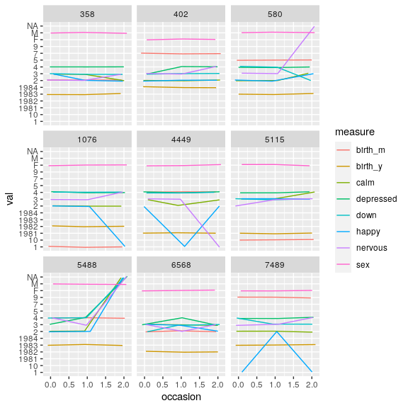

```r
set.seed(1000)
subset <- sample(unique(nlsy97depression$pid), 9)

nlsy97depression %>%
  filter(pid %in% subset) %>%
  gather(measure, val, -pid, -occasion) %>%
  ggplot(aes(x=occasion, group=measure, color=measure, y=val)) +
  geom_line(position=position_jitter(w=0.1, h=0.1)) +
  facet_wrap(~pid)
```

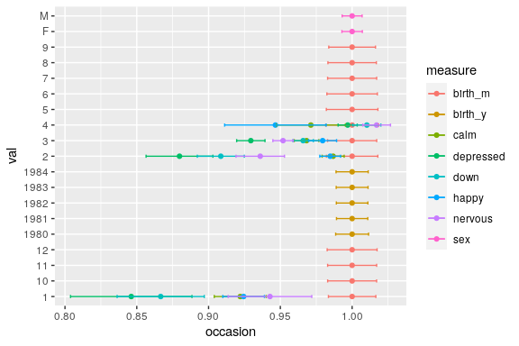

```r
nlsy97depression %>%
  gather(measure, val, -occasion, -pid) %>%
  na.omit() %>%
  ggplot(aes(x=occasion, color=measure, y=val)) +
  stat_summary(fun.y = mean, geom='line') +
  stat_summary(fun.y = mean, geom='point') +
  stat_summary(fun.data = mean_se, geom='errorbar', width=0.2)

```

## C. Example 1: One factor model

We’ll start by building a 1-factor MMOD, with all items loading onto a single latent factor.

```r
structure <- list(
  F1 = c('nervous', 'down', 'depressed', 'calm', 'happy')
)
mmod_model <- mxMmodModel(data=nlsy97depression,
                          modelName='1 Factor MMOD',
                          idvar='pid', timevar='occasion', structure=structure, fiml=F)
mmod_fit <- mxRun(mmod_model)
```

```
#> Running 1 Factor MMOD with 33 parameters
```

```r
(mmod_summary <- summary(mmod_fit))
```

```
#> Summary of 1 Factor MMOD
#>
#> free parameters:
#>                      name matrix          row          col    Estimate
#> 1  1 Factor MMOD.A[19,16]      A   dnervous_1         F1_1  0.34410308
#> 2  1 Factor MMOD.A[20,16]      A      ddown_1         F1_1  0.41640202
#> 3  1 Factor MMOD.A[21,16]      A ddepressed_1         F1_1  0.32588085
#> 4  1 Factor MMOD.A[22,16]      A      dcalm_1         F1_1 -0.37367083
#> 5  1 Factor MMOD.A[23,16]      A     dhappy_1         F1_1 -0.38437697
#> 6  1 Factor MMOD.A[24,17]      A   dnervous_2         F1_2  0.15339125
#> 7  1 Factor MMOD.A[25,17]      A      ddown_2         F1_2  0.26887741
#> 8  1 Factor MMOD.A[26,17]      A ddepressed_2         F1_2  0.21208041
#> 9  1 Factor MMOD.A[27,17]      A      dcalm_2         F1_2 -0.21382244
#> 10 1 Factor MMOD.A[28,17]      A     dhappy_2         F1_2 -0.25476948
#> 11 1 Factor MMOD.A[29,18]      A   dnervous_3         F1_3  0.27951244
```

[output cut: 78 more lines]

The path diagram of this MMOD can be rendered by `semPlot::semPaths`

```r
# Note: This can take a while to draw...
semPlot::semPaths(mmod_fit, 'est')
```

[output not shown]

## D. Example 2: Two factor model

Next, let’s build a two-factor MMOD with one latent factor for negative items (nervous, down, depressed), and the other for positive items (happy, calm):

```r
structure2 <- list(
  F1 = c('nervous', 'down', 'depressed'),
  F2 = c('happy', 'calm')
)
mmod_model2 <- mxMmodModel(data=nlsy97depression,
                          modelName='2 Factor MMOD',
                          idvar='pid', timevar='occasion', structure=structure2)
mmod_fit2 <- mxRun(mmod_model2)
```

```
#> Running 2 Factor MMOD with 45 parameters
```

```r
(mmod_summary2 <- summary(mmod_fit2))
```

```
#> Summary of 2 Factor MMOD
#>
#> free parameters:
#>                      name matrix          row          col    Estimate
#> 1  2 Factor MMOD.A[22,16]      A   dnervous_1         F1_1  0.34208391
#> 2  2 Factor MMOD.A[23,16]      A      ddown_1         F1_1  0.44449759
#> 3  2 Factor MMOD.A[24,16]      A ddepressed_1         F1_1  0.34568966
#> 4  2 Factor MMOD.A[25,17]      A     dhappy_1         F2_1 -0.43364599
#> 5  2 Factor MMOD.A[26,17]      A      dcalm_1         F2_1 -0.40726033
#> 6  2 Factor MMOD.A[27,18]      A   dnervous_2         F1_2 -0.15141710
#> 7  2 Factor MMOD.A[28,18]      A      ddown_2         F1_2 -0.29720493
#> 8  2 Factor MMOD.A[29,18]      A ddepressed_2         F1_2 -0.22737277
#> 9  2 Factor MMOD.A[30,19]      A     dhappy_2         F2_2 -0.31078549
#> 10 2 Factor MMOD.A[31,19]      A      dcalm_2         F2_2 -0.23510537
#> 11 2 Factor MMOD.A[32,20]      A   dnervous_3         F1_3  0.27996036
```

[output cut: 102 more lines]

The path diagram of this MMOD can be rendered by `semPlot::semPaths`

```r
# Note: This can take a while to draw...
semPlot::semPaths(mmod_fit2, 'est')
```

[output not shown]

## E. Discussion

Finally, let’s create a summary table of the fits from the two models so we can compare:

```r
fits <- list(mmod_summary, mmod_summary2)

(compare_models <- tibble(
    name=map_chr(fits, 'modelName'),
    chisq=map_dbl(fits, 'Chi'),
    dof=map_dbl(fits, 'ChiDoF'),
    `-2ll`=map_dbl(fits, 'Minus2LogLikelihood'),
    aic=map_dbl(fits, 'AIC.Mx'),
    bic=map_dbl(fits, 'BIC.Mx'),
    rmsea=map_dbl(fits, 'RMSEA'),
    cfi=map_dbl(fits, 'CFI'),
    tli=map_dbl(fits, 'TLI')
))
```

```
#> # A tibble: 2 x 9
#>   name          chisq   dof `-2ll`   aic   bic  rmsea   cfi   tli
#>   <chr>         <dbl> <dbl>  <dbl> <dbl> <dbl>  <dbl> <dbl> <dbl>
#> 1 1 Factor MMOD 2372.    87 -4384. 2198. 1607. 0.0632 0.928 0.913
#> 2 2 Factor MMOD  839.    75 -5917.  689.  179. 0.0394 0.976 0.966
```

The two-factor model is superior, across every fit metric.